# Basic_eQTL_Analysis_Guide

## loading data

```r
library(readr)
library(tidyr)
library(dplyr)
snps = read_tsv("~/Documents/Postdoc_Projects/First_Project/eQTL_Stroke_011519_Input_Output/Input/MatrixEQTL/data/SNP.txt")
expr = read_tsv("~/Documents/Postdoc_Projects/First_Project/eQTL_Stroke_011519_Input_Output/Input/MatrixEQTL/data/GE.txt")
paste("Mean value of expression for gene ",expr$geneid[1:10]," is ", rowMeans(expr[1:10, -1]))
```

```
##  [1] "Mean value of expression for gene  Gene_01  is  5.0175"
##  [2] "Mean value of expression for gene  Gene_02  is  13.866875"
##  [3] "Mean value of expression for gene  Gene_03  is  13.288125"
##  [4] "Mean value of expression for gene  Gene_04  is  12.0975"
##  [5] "Mean value of expression for gene  Gene_05  is  14.509375"
##  [6] "Mean value of expression for gene  Gene_06  is  12.71375"
##  [7] "Mean value of expression for gene  Gene_07  is  13.806875"
##  [8] "Mean value of expression for gene  Gene_08  is  13.711875"
##  [9] "Mean value of expression for gene  Gene_09  is  10.118125"
## [10] "Mean value of expression for gene  Gene_10  is  13.32125"
```

```r
paste("Standard deviation of expression for gene ", expr$geneid[1:10]," is ", t(apply(expr[1:10, -1], 1, sd)))
```

```
##  [1] "Standard deviation of expression for gene  Gene_01  is  0.37584571302597"
##  [2] "Standard deviation of expression for gene  Gene_02  is  0.85950155128811"
##  [3] "Standard deviation of expression for gene  Gene_03  is  0.822007451304427"
##  [4] "Standard deviation of expression for gene  Gene_04  is  0.697074840553963"
##  [5] "Standard deviation of expression for gene  Gene_05  is  0.742639156432427"
##  [6] "Standard deviation of expression for gene  Gene_06  is  0.360645255063754"
##  [7] "Standard deviation of expression for gene  Gene_07  is  1.14221841898416"
##  [8] "Standard deviation of expression for gene  Gene_08  is  1.14028779262079"
##  [9] "Standard deviation of expression for gene  Gene_09  is  1.34661659354101"
## [10] "Standard deviation of expression for gene  Gene_10  is  0.862367864274483"
```

```r
paste("Mean value for SNP ",snps$snpid[1:15]," is ", rowMeans(snps[1:15, -1]))
```

```
##  [1] "Mean value for SNP  Snp_01  is  1.375"
##  [2] "Mean value for SNP  Snp_02  is  0.8125"
##  [3] "Mean value for SNP  Snp_03  is  0.8125"
##  [4] "Mean value for SNP  Snp_04  is  0.9375"
##  [5] "Mean value for SNP  Snp_05  is  1.125"
##  [6] "Mean value for SNP  Snp_06  is  1.1875"
##  [7] "Mean value for SNP  Snp_07  is  1.0625"
##  [8] "Mean value for SNP  Snp_08  is  0.6875"
##  [9] "Mean value for SNP  Snp_09  is  0.9375"
## [10] "Mean value for SNP  Snp_10  is  0.9375"
## [11] "Mean value for SNP  Snp_11  is  1.25"
## [12] "Mean value for SNP  Snp_12  is  1.125"
## [13] "Mean value for SNP  Snp_13  is  0.9375"
## [14] "Mean value for SNP  Snp_14  is  0.8125"
## [15] "Mean value for SNP  Snp_15  is  1.375"
```

```r
paste("Standard deviation of expression for SNP ", " is ", t(apply(snps[1:15, -1], 1, sd)))
```

```
##  [1] "Standard deviation of expression for SNP   is  0.718795288428261"
##  [2] "Standard deviation of expression for SNP   is  0.655108133567785"
##  [3] "Standard deviation of expression for SNP   is  0.543905629069357"
##  [4] "Standard deviation of expression for SNP   is  0.771902411793961"
##  [5] "Standard deviation of expression for SNP   is  0.61913918736689"
##  [6] "Standard deviation of expression for SNP   is  0.75"
##  [7] "Standard deviation of expression for SNP   is  0.680073525436772"
##  [8] "Standard deviation of expression for SNP   is  0.602079728939615"
##  [9] "Standard deviation of expression for SNP   is  0.771902411793961"
## [10] "Standard deviation of expression for SNP   is  0.680073525436772"
## [11] "Standard deviation of expression for SNP   is  0.774596669241483"
## [12] "Standard deviation of expression for SNP   is  0.718795288428261"
## [13] "Standard deviation of expression for SNP   is  0.680073525436772"
## [14] "Standard deviation of expression for SNP   is  0.75"
## [15] "Standard deviation of expression for SNP   is  0.61913918736689"
```

## The term MAF implies that the allele for which we return the measure has to be the minor (= less common) allele. This means that the MAF is smaller than 0.5 by definition.So let’s now calculate the MAF for all SNPs among all individuals and correct the returned values so that the value is always given in respect to the minor allele. Then we’ll plot a histogram of the MAFs of all SNPs

```r
library(MASS)
maf = rowMeans(snps[-1])/2
sum(maf > 0.5) # so there are 7 alleses which are actually major alleles in this population sample
```

```
## [1] 7
```

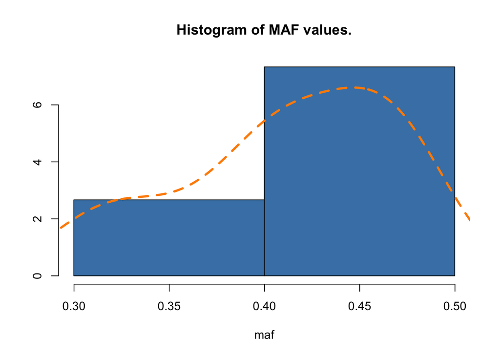

```r
# To ensure we actually get the MAF this needs to be inverted.
maf <- pmin(maf, 1-maf)

truehist(maf, main = "Histogram of MAF values.", col = "steelblue")
lines(density(maf), lty = 2, col = "darkorange", lwd = 3)
```

##Filtering SNPs by MAF: In an eQTL study often a minimum MAF is required. Since MAF essentially reflects how often an allele has been observed in a population, it also defines how often the gene expression levels have been observed for heterozygous and homozygous alleles. We need to know what useful MAF thresholds are for SNPs to include in an eQTL analysis.

```r
#here the e.g for MAF of 5%, 10% and 15% in a sample of 500 individuals
p = c(0.05, 0.1, 0.15)
q = 1-p
# Calulate frequency of minor allele being present in homozygous and heterozygous state
f_hom = p^2
f_het = 2*p*q
# Expected number of observations in a sample size of 500
sample_size = 500
round(f_hom * sample_size)
```

```
## [1]  1  5 11
```

```r
round(f_het * sample_size)
```

```
## [1]  48  90 128
```

# Now that we have an idea of what is stored in the genotype data frame let’s take a look at the expression data. For eQTL analyses it is important for the gene expression to be normally distributed among samples, therefore RNA-seq data has to be transformed by, for example quantile normalization. Let’s check the distribution of gene expression levels across samples for the first gene in our expr data frame.’

```r
gname = expr$geneid[1]
gname
```

```
## [1] "Gene_01"
```

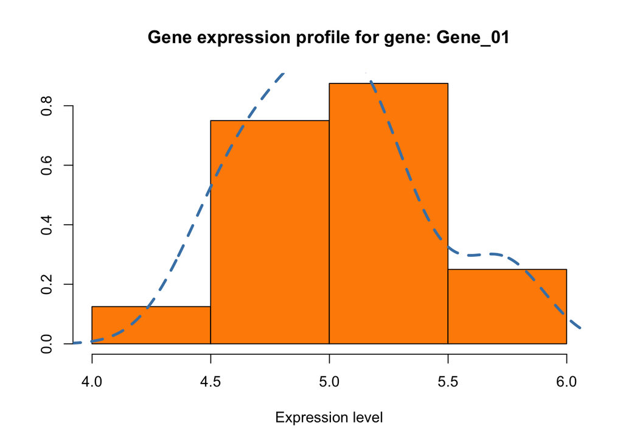

```r
truehist(as.numeric(filter(expr, geneid == gname)[-1]), main = paste("Gene expression profile for gene:",gname), xlab = "Expression level", col = "darkorange")
# same as truehist(as.numeric(expr[1,-1]))
lines(density(as.numeric(filter(expr, geneid == gname)[-1])), lty = 2, col = "steelblue", lwd = 3)
```

## Now we’ll plot the expression levels of the first gene against the first SNP, 10th gene against the 10th SNP, 10th gene against the 1th SNP, as well as the 10th gene against the 6th SNP, depending on the genotypes of the samples by using simple dot plots. We’ll add a bit of random noise (jitter) to the genotype data to make it all look more comprehensible.

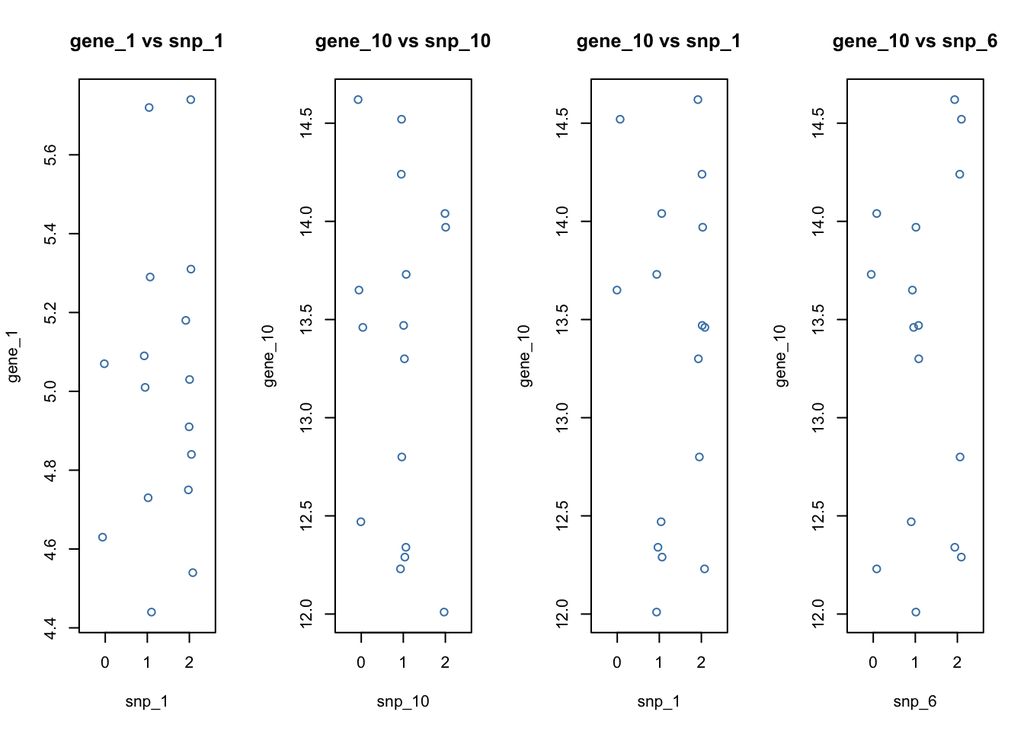

```r
genotype = c("snp_1", "snp_10", "snp_1", "snp_6")
genes = c("gene_1", "gene_10", "gene_10", "gene_10")
par(mfrow=c(1,length(genotype)))

plot(jitter(as.numeric(snps[1,-1]), factor = 0.5), as.numeric(expr[1,-1]),
     xlab = genotype[1], ylab = genes[1], col = "steelblue",
     main = paste(genes[1], "vs", genotype[1]), xlim= c(-0.5,2.5), xaxt="n")
axis(1, at =c (0,1,2), labels = c("0", "1", "2"))
plot(jitter(as.numeric(snps[10,-1]), factor = 0.5), as.numeric(expr[10,-1]),
     xlab = genotype[2], ylab = genes[2], col = "steelblue",
     main = paste(genes[2], "vs", genotype[2]), xlim= c(-0.5,2.5), xaxt="n")
axis(1, at =c (0,1,2), labels = c("0", "1", "2"))
plot(jitter(as.numeric(snps[1,-1]), factor = 0.5), as.numeric(expr[10,-1]),
     xlab = genotype[3], ylab = genes[3], col = "steelblue",
     main = paste(genes[3], "vs", genotype[3]), xlim= c(-0.5,2.5), xaxt="n")
axis(1, at =c (0,1,2), labels = c("0", "1", "2"))
plot(jitter(as.numeric(snps[6,-1]), factor = 0.5), as.numeric(expr[10,-1]),
     xlab = genotype[4], ylab = genes[4], col = "steelblue",
     main = paste(genes[4], "vs", genotype[4]), xlim= c(-0.5,2.5), xaxt="n")
axis(1, at =c (0,1,2), labels = c("0", "1", "2"))
```

##Let’s do a bit of data wrangling for easier downstream analysis and efficient plotting. Namely we’ll transpose our data frames so that we have variables, i.e. SNPs and expression levels as columns and samples as rows.

```r
expr_trans = data.frame(t(expr[, -1]))
colnames(expr_trans)=t(expr[, 1])
expr_trans = tibble::rownames_to_column(expr_trans, "sample")
head(expr_trans)[1:10]
```

```
##   sample Gene_01 Gene_02 Gene_03 Gene_04 Gene_05 Gene_06 Gene_07 Gene_08
## 1 Sam_01    4.91   13.78   12.06   11.63   14.72   12.29   12.56   12.27
## 2 Sam_02    4.63   13.14   12.29   11.88   14.66   12.23   12.71   12.58
## 3 Sam_03    5.18   13.18   13.07   12.74   14.63   12.47   12.49   12.61
## 4 Sam_04    5.07   13.04   13.65   12.66   15.91   13.21   13.41   13.02
## 5 Sam_05    5.74   12.85   13.86   13.16   15.46   12.63   13.60   12.86
## 6 Sam_06    5.09   13.07   12.84   11.99   14.74   12.18   12.35   12.32
##   Gene_09
## 1    9.82
## 2    9.29
## 3    8.95
## 4    8.18
## 5    8.11
## 6    9.43
```

### and the same for genotype data

```r
snps_trans <- data.frame(t(snps[,-1]))
colnames(snps_trans) <- t(snps[,1])
snps_trans <- tibble::rownames_to_column(snps_trans, "sample") #consider samples as a column for rowname lable
head(snps_trans)[1:10]
```

```
##   sample Snp_01 Snp_02 Snp_03 Snp_04 Snp_05 Snp_06 Snp_07 Snp_08 Snp_09
## 1 Sam_01      2      0      1      0      1      2      1      1      2
## 2 Sam_02      0      1      0      1      1      2      1      0      1
## 3 Sam_03      2      1      1      2      2      2      2      1      2
## 4 Sam_04      0      2      0      2      1      1      2      0      2
## 5 Sam_05      2      2      1      2      1      1      0      1      0
## 6 Sam_06      1      1      1      1      2      0      1      0      1
```

```r
library(ggplot2)

#Reshape dataframes a bit for use with ggplot2, remeber this function
snps_long = tidyr::gather(snps_trans[, 1:5], snp, genotype, -sample)
expr_long = tidyr::gather(expr_trans[, 1:5], gene, expression, -sample)
head(snps_long)
```

```
##   sample    snp genotype
## 1 Sam_01 Snp_01        2
## 2 Sam_02 Snp_01        0
## 3 Sam_03 Snp_01        2
## 4 Sam_04 Snp_01        0
## 5 Sam_05 Snp_01        2
## 6 Sam_06 Snp_01        1
```

```r
data_long <- cbind(snps_long, expr_long["expression"])
data_long$genotype <- as.factor(data_long$genotype)
head(data_long)
```

```
##   sample    snp genotype expression
## 1 Sam_01 Snp_01        2       4.91
## 2 Sam_02 Snp_01        0       4.63
## 3 Sam_03 Snp_01        2       5.18
## 4 Sam_04 Snp_01        0       5.07
## 5 Sam_05 Snp_01        2       5.74
## 6 Sam_06 Snp_01        1       5.09
```

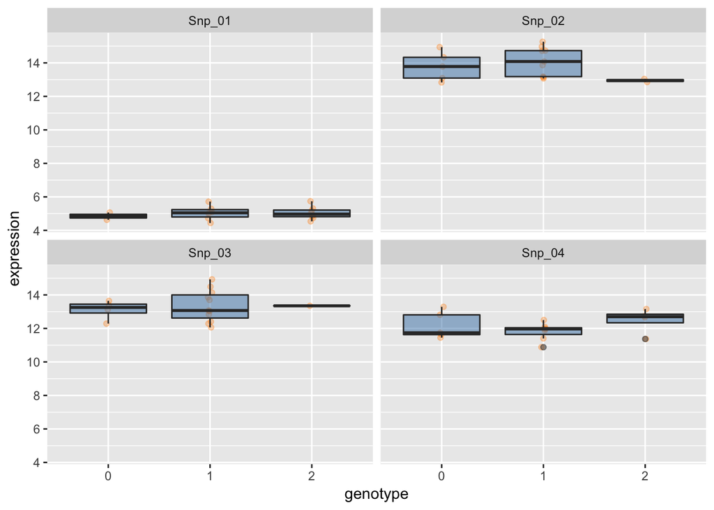

```r
ggplot(data_long, aes(genotype, expression)) +
  geom_jitter(colour = "darkorange",alpha = 0.3, width = 0.02) +
  geom_boxplot(alpha = 0.5, fill = "steelblue") +
  facet_wrap(~snp)
```

### Let’s do that for more SNPs and genes, just to see whether we could catch any visible correlations

```r
snps_long = tidyr::gather(snps_trans[, 1:10], snp, genotype, -sample)
expr_long = tidyr::gather(expr_trans[, 1:10], gene, expression, -sample)
head(snps_long)
```

```
##   sample    snp genotype
## 1 Sam_01 Snp_01        2
## 2 Sam_02 Snp_01        0
## 3 Sam_03 Snp_01        2
## 4 Sam_04 Snp_01        0
## 5 Sam_05 Snp_01        2
## 6 Sam_06 Snp_01        1
```

```r
data_long <- cbind(snps_long, expr_long["expression"])
data_long$genotype <- as.factor(data_long$genotype)
head(data_long)
```

```
##   sample    snp genotype expression
## 1 Sam_01 Snp_01        2       4.91
## 2 Sam_02 Snp_01        0       4.63
## 3 Sam_03 Snp_01        2       5.18
## 4 Sam_04 Snp_01        0       5.07
## 5 Sam_05 Snp_01        2       5.74
## 6 Sam_06 Snp_01        1       5.09
```

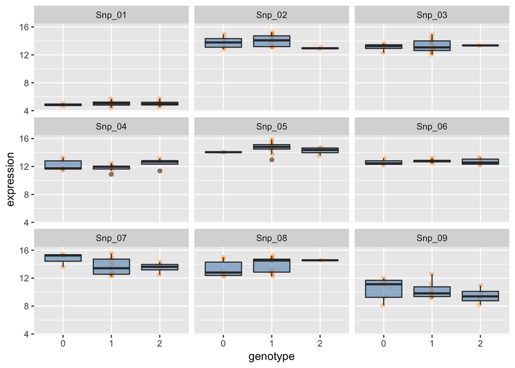

```r
ggplot(data_long, aes(genotype, expression)) +
  geom_jitter(colour = "darkorange",alpha = 0.3, width = 0.02) +
  geom_boxplot(alpha = 0.5, fill = "steelblue",
               position = position_dodge(width = 0)) +
  facet_wrap(~snp)
```

##Understanding the basics, This script explain the basic ideas behind eQTL analyses and how eQTL mapping works in general. ##Linear regression of genotype on phenotype:The most common way of estimating the effect of a SNP on gene expression is by performing a linear regression of sample genotypes on sample gene expression levels. So to obtain estimates of the genotypic contribution to gene expression we fit a simple linear regression model of the form Ei=β0+βGi+ϵ, where Ei is the vector of gene expression values for gene i and Gi is the genotype vector for the SNPi. We are interested in the estimate for β which indicates the change in gene expression for each copy of the second allele. The p-value indicates the significance of the genetic component in the model. Let’s try that for gene 10 with SNP 1 and SNP 6.

```r
#Gene 10 with SNP 1
lm_1_10 = lm(expr_trans[, 11] ~ snps_trans[, 2]) #don’t catch any significant effect of explored SNPs and gene expression levels. NO eQTL
summary(lm_1_10)
```

```
##
## Call:
## lm(formula = expr_trans[, 11] ~ snps_trans[, 2])
##
## Residuals:
##     Min      1Q  Median      3Q     Max
## -1.3116 -0.8841  0.1444  0.6666  1.2994
##
## Coefficients:
##                   Estimate Std. Error t value Pr(>|t|)
## (Intercept)     13.3225806  0.4941457  26.961 1.82e-13 ***
## snps_trans[, 2] -0.0009677  0.3206440  -0.003    0.998
## ---
## Signif. codes:  0 '***' 0.001 '**' 0.01 '*' 0.05 '.' 0.1 ' ' 1
##
## Residual standard error: 0.8926 on 14 degrees of freedom
## Multiple R-squared:  6.506e-07,  Adjusted R-squared:  -0.07143
## F-statistic: 9.109e-06 on 1 and 14 DF,  p-value: 0.9976
```

```r
#                   Estimate Std. Error t value Pr(>|t|)
# (Intercept)     13.3225806  0.4941457  26.961 1.82e-13 ***
# snps_trans[, 2] -0.0009677  0.3206440  -0.003    0.998
```

```r
#Gene 10 with SNP 6
lm_6_10 = lm(expr_trans[, 11] ~ snps_trans[, 7]) #don’t catch any significant effect of explored SNPs and gene expression levels. NO eQTL
summary(lm_6_10)
```

```
##
## Call:
## lm(formula = expr_trans[, 11] ~ snps_trans[, 7])
##
## Residuals:
##     Min      1Q  Median      3Q     Max
## -1.2924 -0.8674  0.1626  0.7100  1.2173
##
## Coefficients:
##                 Estimate Std. Error t value Pr(>|t|)
## (Intercept)      13.2021     0.4261  30.982 2.67e-14 ***
## snps_trans[, 7]   0.1003     0.3061   0.328    0.748
## ---
## Signif. codes:  0 '***' 0.001 '**' 0.01 '*' 0.05 '.' 0.1 ' ' 1
##
## Residual standard error: 0.8892 on 14 degrees of freedom
## Multiple R-squared:  0.007609,   Adjusted R-squared:  -0.06328
## F-statistic: 0.1073 on 1 and 14 DF,  p-value: 0.748
```

```r
#                 Estimate Std. Error t value Pr(>|t|)
# (Intercept)      13.2021     0.4261  30.982 2.67e-14 ***
# snps_trans[, 7]   0.1003     0.3061   0.328    0.748
```

```r
gt = read_tsv("~/Documents/Postdoc_Projects/First_Project/eQTL_Stroke_011519_Input_Output/Input/MatrixEQTL/data/SNP.txt")
gt_trans <- data.frame(t(gt[,-1]))
colnames(gt_trans) <- t(gt[,1])
gt_trans <- tibble::rownames_to_column(gt_trans, "sample") #consider samples as a column for rowname lable
head(snps_trans)[1:10]
```

```
##   sample Snp_01 Snp_02 Snp_03 Snp_04 Snp_05 Snp_06 Snp_07 Snp_08 Snp_09
## 1 Sam_01      2      0      1      0      1      2      1      1      2
## 2 Sam_02      0      1      0      1      1      2      1      0      1
## 3 Sam_03      2      1      1      2      2      2      2      1      2
## 4 Sam_04      0      2      0      2      1      1      2      0      2
## 5 Sam_05      2      2      1      2      1      1      0      1      0
## 6 Sam_06      1      1      1      1      2      0      1      0      1
```

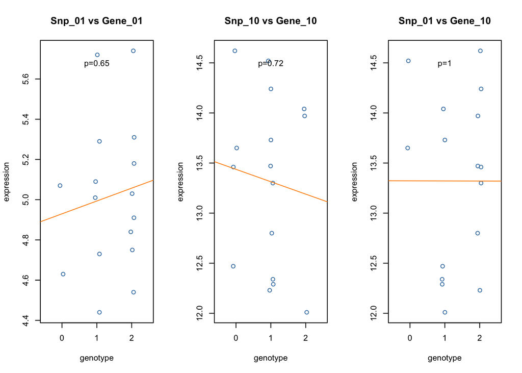

```r
snps = c("Snp_01", "Snp_10", "Snp_01")
genes = c("Gene_01", "Gene_10", "Gene_10")
par(mfrow=c(1,length(snps)))

for (index in seq(length(snps))){
  genotype = gt_trans[[snps[index]]]
  expression = expr_trans[[genes[index]]]
  lm_result = lm(expression ~ genotype)
  plot(jitter(genotype, factor = 0.4), expression,
  main=paste(snps[index], "vs", genes[index]), xlim= c(-0.5,2.5),
  xlab = "genotype", xaxt="n", col ="steelblue")
  abline(lm_result, col="darkorange")
  axis(1, at=c(0,1,2), labels = c("0", "1", "2"))
  # Add p-values as text
  y_range = range(expression)
  text(x=1, y=y_range[1] + 0.95*diff(y_range), paste0("p=",
  format(summary(lm_result)$coefficients[2,4],
  scentific=TRUE, digits=2)))
  }
```

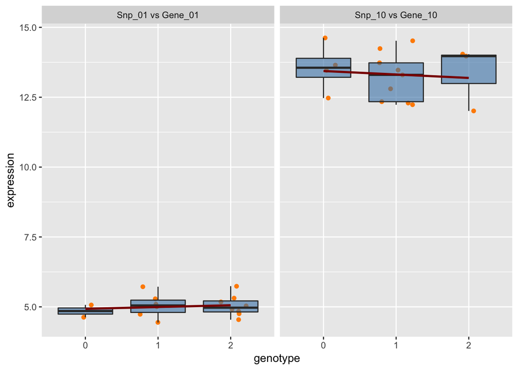

```r
#with ggplot

genoLong = tidyr::gather(gt_trans, snp, genotype, Snp_01, Snp_10) #just for these two snps we want to have column seperately
exprLong = tidyr::gather(expr_trans, gene, expression, Gene_01, Gene_10)
dataLong = cbind(genoLong[,c("snp", "genotype")], exprLong[,c("gene", "expression")])
dataLong$comparison = paste(dataLong$snp, "vs", dataLong$gene)
dataLong$genotype = factor(dataLong$genotype)

ggplot(dataLong, aes(genotype, expression)) +
    geom_jitter(col="darkorange", position=position_jitter(width=0.25)) +
    geom_boxplot(outlier.size=0, alpha=0.6, fill="steelblue") +
    geom_smooth(method = 'lm',col="darkred", aes(group=1), se=FALSE) +
    facet_wrap(~comparison)
```